# Project_Statistical_Learning_Sanju_Mathew

## Sanju Mathew - Project on Statistical Learning

### Step 1 - Import the necessary libraries

```python
import numpy as np
import pandas as pd
import seaborn as sns
import matplotlib.pyplot as plt
import statsmodels.api as sm

from scipy.stats import zscore, ttest_ind
from statsmodels.stats.proportion import proportions_ztest
from statsmodels.formula.api import ols
from statsmodels.stats.multicomp import pairwise_tukeyhsd

sns.set(style="whitegrid", color_codes=True)
sns.set_palette("Set1")
%matplotlib inline
```

### Step 2 - Read the data as a data frame

```python
df = pd.read_csv("insurance.csv")
df.rename(columns = {'age' : 'Age', 'sex':'Gender', 'bmi':'BMI', 'children':'Children', 'smoker':'Smoker', 'region':'Region', 'charges':'Charges'}, inplace=True)
df.head()
```

|  | Age | Gender | BMI | Children | Smoker | Region | Charges |
| --- | --- | --- | --- | --- | --- | --- | --- |
| 0 | 19 | female | 27.900 | 0 | yes | southwest | 16884.92400 |
| 1 | 18 | male | 33.770 | 1 | no | southeast | 1725.55230 |
| 2 | 28 | male | 33.000 | 3 | no | southeast | 4449.46200 |
| 3 | 33 | male | 22.705 | 0 | no | northwest | 21984.47061 |
| 4 | 32 | male | 28.880 | 0 | no | northwest | 3866.85520 |

### Step 3A - Shape of the data

- Insurance data provided has the shape of (1338, 7).
- There are 1338 rows and 7 columns in the data provided.

```python
df.shape
```

```
(1338, 7)
```

### Step 3B - Data type of each attribute

- Categorical variables (Binary) - Gender, Smoker; (Nominal) - Region.
- Discrete variables - Age, Children.
- Continuous variables - BMI, Charges.

```python
df.info()
```

```
<class 'pandas.core.frame.DataFrame'>
RangeIndex: 1338 entries, 0 to 1337
Data columns (total 7 columns):
Age         1338 non-null int64
Gender      1338 non-null object
BMI         1338 non-null float64
Children    1338 non-null int64
Smoker      1338 non-null object
Region      1338 non-null object
Charges     1338 non-null float64
dtypes: float64(2), int64(2), object(3)
memory usage: 73.2+ KB
```

### Step 3C - Checking the presence of missing values

- There are no missing or null values in the data.

```python
df.isnull().sum()
```

```
Age         0
Gender      0
BMI         0
Children    0
Smoker      0
Region      0
Charges     0
dtype: int64
```

```python
df.isna().apply(pd.value_counts)
```

|  | Age | Gender | BMI | Children | Smoker | Region | Charges |
| --- | --- | --- | --- | --- | --- | --- | --- |
| False | 1338 | 1338 | 1338 | 1338 | 1338 | 1338 | 1338 |

```python
dupes = pd.DataFrame()
dupes['D'] = df.duplicated()
dupes[dupes.D == True].index
```

```
Int64Index([581], dtype='int64')
```

```python
df[df.index == 581]
```

|  | Age | Gender | BMI | Children | Smoker | Region | Charges |
| --- | --- | --- | --- | --- | --- | --- | --- |
| 581 | 19 | male | 30.59 | 0 | no | northwest | 1639.5631 |

```python
df[df.Charges == 1639.5631]
```

|  | Age | Gender | BMI | Children | Smoker | Region | Charges |
| --- | --- | --- | --- | --- | --- | --- | --- |
| 195 | 19 | male | 30.59 | 0 | no | northwest | 1639.5631 |
| 581 | 19 | male | 30.59 | 0 | no | northwest | 1639.5631 |

- Dropping a duplicate found in the data

```python
df.drop(index= 581, inplace=True)
df.shape
```

```
(1337, 7)
```

### Step 3D - 5 point summary of numerical attributes

- Age - Median and mean seems to be very close at 39 and 39.2 representing possibility of data to be symmetric.
- BMI - Median of 30.4 and mean of 30.66 appear to be normally distributed.
- Charges - Median of 9386 and mean of 13279 shows a huge difference. Data appear to be right skewed.
- Children - Values have a range from 0 to 5.
- All values for Age, BMI & Charges appear to be complete as min values do not have '0'.

```python
df.describe(include = "all").T
```

|  | count | unique | top | freq | mean | std | min | 25% | 50% | 75% | max |
| --- | --- | --- | --- | --- | --- | --- | --- | --- | --- | --- | --- |
| Age | 1337 | NaN | NaN | NaN | 39.2221 | 14.0443 | 18 | 27 | 39 | 51 | 64 |
| Gender | 1337 | 2 | male | 675 | NaN | NaN | NaN | NaN | NaN | NaN | NaN |
| BMI | 1337 | NaN | NaN | NaN | 30.6635 | 6.10047 | 15.96 | 26.29 | 30.4 | 34.7 | 53.13 |
| Children | 1337 | NaN | NaN | NaN | 1.09574 | 1.20557 | 0 | 0 | 1 | 2 | 5 |
| Smoker | 1337 | 2 | no | 1063 | NaN | NaN | NaN | NaN | NaN | NaN | NaN |
| Region | 1337 | 4 | southeast | 364 | NaN | NaN | NaN | NaN | NaN | NaN | NaN |
| Charges | 1337 | NaN | NaN | NaN | 13279.1 | 12110.4 | 1121.87 | 4746.34 | 9386.16 | 16657.7 | 63770.4 |

### Step 3E - Distribution of ‘bmi’, ‘age’ and ‘charges’ columns.

#### Distribution of ‘BMI’

- Appears to be 'Normally Distributed'.

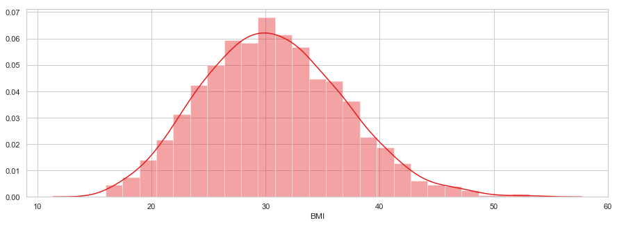

```python
plt.figure(figsize=(15,5))
sns.distplot(df['BMI'])
```

#### Distribution of ‘Age’

- Age of primary beneficiaries appear to be almost a 'Uniform Distribution'.
- Number of counts for age 18 and 19 is more than double of rest of the age groups.

```
Age 18: 69 | Age 19: 67 | Age 20: 29
```

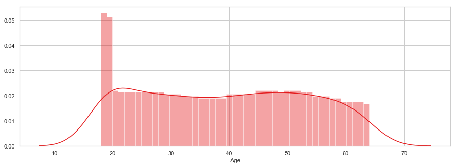

```python
plt.figure(figsize=(15,5))
sns.distplot(df['Age'], bins = df.Age.nunique())
print("Age 18:", len(df[df['Age'] == 18]), "| Age 19:", len(df[df['Age'] == 19]), "| Age 20:", len(df[df['Age'] == 20]))
```

#### Distribution of ‘Charges’

- Charges appeared to be right skewed, hence a further analysis was done based on 'Smoker' and then based on 'BMI'.

```
Right skewed distribution of charges
```

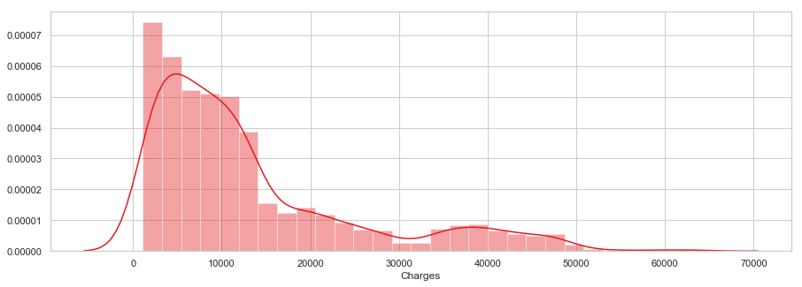

```python
plt.figure(figsize=(15,5))
sns.distplot(df['Charges'])
print("Right skewed distribution of charges")
```

```
 Red: Non-smokers
 Blue: Smokers with less than 30.4 BMI
 Green: Smokers with more than 30.4 BMI
```

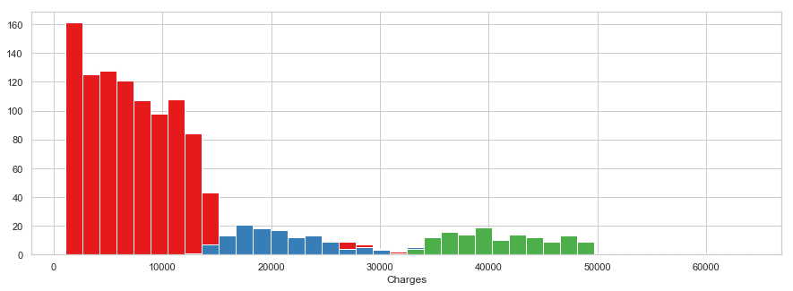

```python
plt.figure(figsize=(15,5))
a = df[df['Smoker'] == 'no']['Charges']
b = df[(df['Smoker'] == 'yes') & (df['BMI'] < 30.4)]['Charges']
c = df[(df['Smoker'] == 'yes') & (df['BMI'] >= 30.4)]['Charges']
bins=np.histogram(np.hstack((a,b,c)), bins=40)[1]
plt.hist(a, bins)
plt.hist(b, bins)
plt.hist(c, bins)
plt.xlabel('Charges')
print(" Red: Non-smokers", "\n", "Blue: Smokers with less than 30.4 BMI", "\n", "Green: Smokers with more than 30.4 BMI")
```

- Charges for Non-smoker is right skewed, which could be related to another attribute.
- Further analysis revealed that charges vary based on 'Smoker' and 'Non-Smoker'.
- Charges for 'Smokers' are higher than 'Non-Smokers'.
- And for 'Smokers' charges increase further if they are above 'BMI' of 30.4.

### Step 3F - Measure of skewness of ‘bmi’, ‘age’ and ‘charges’ columns

As described earlier

- BMI has 'Normal Distribution' and data has a small positive skew of 0.28
- Age is almost flat with a 'Uniform Distribution' and data has a small positive skew of 0.05
- Charges are right skewed by 1.51; This is mainly because of the increase in charges for Smokers relative to Non-smokers.
- Charges of Smokers are bimodal which lead to further analysis.

This can be further visualised in the boxplot below.

```python
df_n = df[['BMI','Age','Charges']]
df_n.skew(axis = 0)
```

```
BMI        0.283914
Age        0.054781
Charges    1.515391
dtype: float64
```

### Step 3G - Checking the presence of outliers in ‘bmi’, ‘age’ and ‘charges’ columns

- Since the data is in different dimensions it is standardised to z score.
- BMI has few outliers on the right side of distribution that are beyond 1.5 times of IQR.
- Charges have lot of outliers on the right side beyond 1.5 times of IQR when the charges are considered as one data.

```python
df_n = df_n.apply(zscore)
df_n.head()
```

|  | BMI | Age | Charges |
| --- | --- | --- | --- |
| 0 | -0.453160 | -1.440418 | 0.297857 |
| 1 | 0.509422 | -1.511647 | -0.954381 |
| 2 | 0.383155 | -0.799350 | -0.729373 |
| 3 | -1.305052 | -0.443201 | 0.719104 |
| 4 | -0.292456 | -0.514431 | -0.777499 |

```
Boxplot of BMI, Age and Charges standardised to z score
```

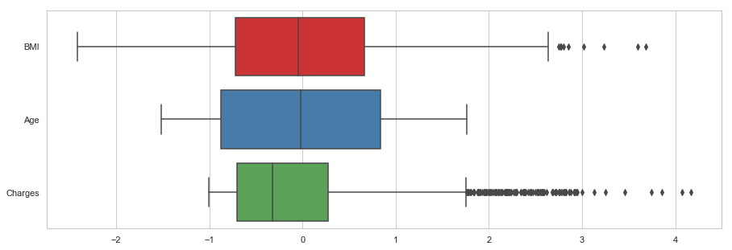

```python
plt.figure(figsize=(15,5))
sns.boxplot(data=df_n, orient="h")
print("Boxplot of BMI, Age and Charges standardised to z score")
```

```
Boxplot of Charges on the basis of Non-smoker, Smoker with less than 30.4 BMI & Smoker with more than 30.4 BMI
```

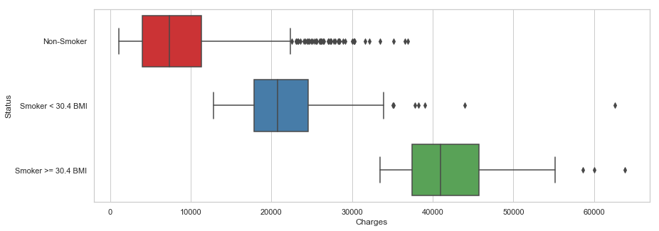

```python
df_Charges = pd.DataFrame()
df_Charges = df_Charges.append(pd.DataFrame({'Status': 'Non-Smoker', 'Charges':df[df['Smoker'] == 'no']['Charges']}))
df_Charges = df_Charges.append(pd.DataFrame({'Status': 'Smoker < 30.4 BMI', 'Charges':df[(df['Smoker'] == 'yes') & (df['BMI'] < 30.4)]['Charges']}))
df_Charges = df_Charges.append(pd.DataFrame({'Status': 'Smoker >= 30.4 BMI', 'Charges':df[(df['Smoker'] == 'yes') & (df['BMI'] >= 30.4)]['Charges']}))

plt.figure(figsize=(14,5))
sns.boxplot(x = df_Charges.Charges, y = df_Charges.Status, orient="h")
print("Boxplot of Charges on the basis of Non-smoker, Smoker with less than 30.4 BMI & Smoker with more than 30.4 BMI")
```

- Boxplot plotted based on Non-smoker, Smoker with less than 30.4 BMI and more than 30.4 BMI.
- All 3 categories are still right skewed with outliers.

### Step 3H - Distribution of categorical columns (include children)

#### Distribution of ‘Smokers’

- Proportion of male smokers appear to be 6% (23-17) higher than female smokers.

| Gender Smoker | female | male | All |
| --- | --- | --- | --- |
| no | 0.826284 | 0.764444 | 0.795064 |
| yes | 0.173716 | 0.235556 | 0.204936 |

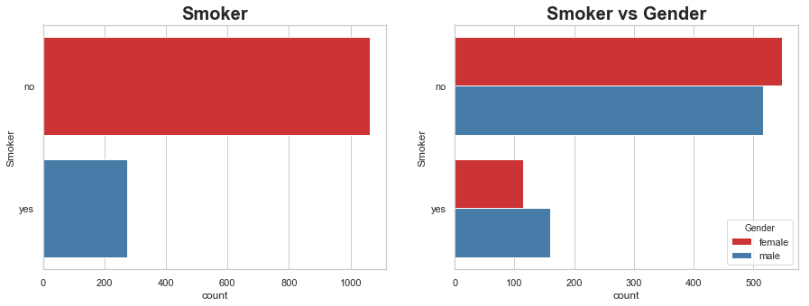

```python
f, ax = plt.subplots(1, 2, figsize = (15,5))
sns.countplot(y='Smoker', order = df.Smoker.value_counts().index, data=df, ax = ax[0])
ax[0].set_title("Smoker", size = 20, weight = "bold")
sns.countplot(y='Smoker', order = df.Smoker.value_counts().index, hue = 'Gender', data=df, ax = ax[1])
ax[1].set_title("Smoker vs Gender", size = 20, weight = "bold")

pd.crosstab(df['Smoker'], df['Gender'], normalize = 'columns', margins = True)
```

#### Distribution of ‘Children’

- Proportion of primary beneficiaries with no or one child are 7% higher in Southeast relative to Northwest.

| Region Children | NorthWest | SouthEast |
| --- | --- | --- |
| 0 | 0.192364 | 0.230543 |
| 1 | 0.108664 | 0.139501 |
| 2 | 0.096916 | 0.096916 |
| 3 | 0.067548 | 0.051395 |
| 4 | 0.008811 | 0.007342 |

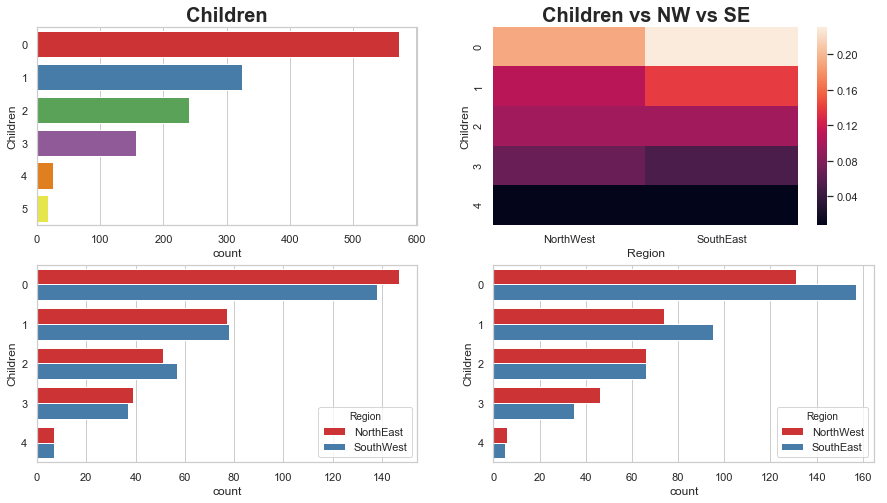

```python
df_RNW = pd.DataFrame()
df_RNW = df_RNW.append(pd.DataFrame({'Region': 'NorthWest', 'Children':df[(df['Region'] == 'northwest') & (df['Children'] < 5)]['Children']}))
df_RNW = df_RNW.append(pd.DataFrame({'Region': 'SouthEast', 'Children':df[(df['Region'] == 'southeast') & (df['Children'] < 5)]['Children']}))

df_RNE = pd.DataFrame()
df_RNE = df_RNE.append(pd.DataFrame({'Region': 'NorthEast', 'Children':df[(df['Region'] == 'northeast') & (df['Children'] < 5)]['Children']}))
df_RNE = df_RNE.append(pd.DataFrame({'Region': 'SouthWest', 'Children':df[(df['Region'] == 'southwest') & (df['Children'] < 5)]['Children']}))

df_RNWSE = pd.crosstab(df_RNW['Children'], df_RNW['Region'], normalize = True)

f, ax = plt.subplots(2, 2, figsize = (15,8))
ax[0,0].set_title("Children", size = 20, weight = "bold")
ax[0,1].set_title("Children vs NW vs SE", size = 20, weight = "bold")
sns.countplot(y='Children', order = df.Children.value_counts().index, data=df, ax = ax[0,0])
sns.heatmap(df_RNWSE, ax = ax[0,1])
sns.countplot(y='Children', hue = 'Region', data=df_RNE, ax = ax[1,0])
sns.countplot(y='Children', hue = 'Region', data=df_RNW, ax = ax[1,1])

df_RNWSE.head()
```

#### Distribution of ‘Region’

- Proportion of smokers in southeast are 5% more (25-20) than average smokers of US.

| Smoker Region | no | yes |
| --- | --- | --- |
| northeast | 0.793210 | 0.206790 |
| northwest | 0.820988 | 0.179012 |
| southeast | 0.750000 | 0.250000 |
| southwest | 0.821538 | 0.178462 |
| All | 0.795064 | 0.204936 |

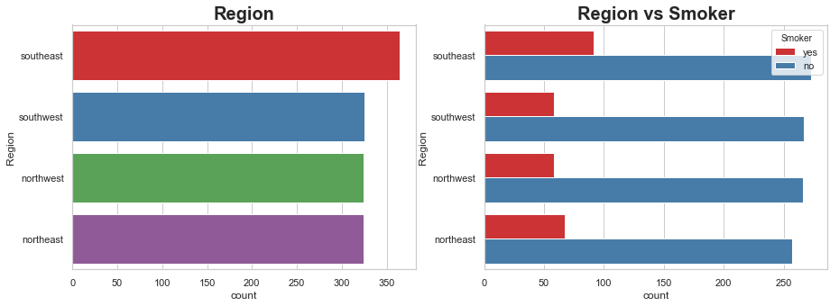

```python
f, ax = plt.subplots(1, 2, figsize = (15,5))
sns.countplot(y='Region', order = df.Region.value_counts().index, data=df, ax = ax[0])
ax[0].set_title("Region", size = 20, weight = "bold")
sns.countplot(y='Region', order = df.Region.value_counts().index, hue = 'Smoker', data=df, ax = ax[1])
ax[1].set_title("Region vs Smoker", size = 20, weight = "bold")

pd.crosstab(df['Region'], df['Smoker'], normalize = 'index', margins = True)
```

#### Distribution of ‘Gender’

- Proportion of males in southeast are 4% more (52-48) relative to females in same region.

| Region Gender | northeast | northwest | southeast | southwest | All |
| --- | --- | --- | --- | --- | --- |
| female | 0.496914 | 0.506173 | 0.480769 | 0.498462 | 0.495138 |
| male | 0.503086 | 0.493827 | 0.519231 | 0.501538 | 0.504862 |

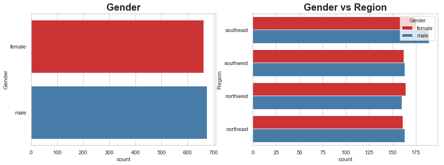

```python
f, ax = plt.subplots(1, 2, figsize = (15,5))
sns.countplot(y='Gender', order = ['female', 'male'], data=df, ax = ax[0])
ax[0].set_title("Gender", size = 20, weight = "bold")
sns.countplot(y='Region', order = df.Region.value_counts().index, hue = 'Gender', data=df, ax = ax[1])
ax[1].set_title("Gender vs Region", size = 20, weight = "bold")

pd.crosstab(df['Gender'], df['Region'], normalize = 'columns', margins = True)
```

### Step 3I - Pair plot that includes all the columns of the data frame

- Charges appear to be increasing based on Age and Smokers.
- Charges appear to be increasing based on BMI for Smokers.

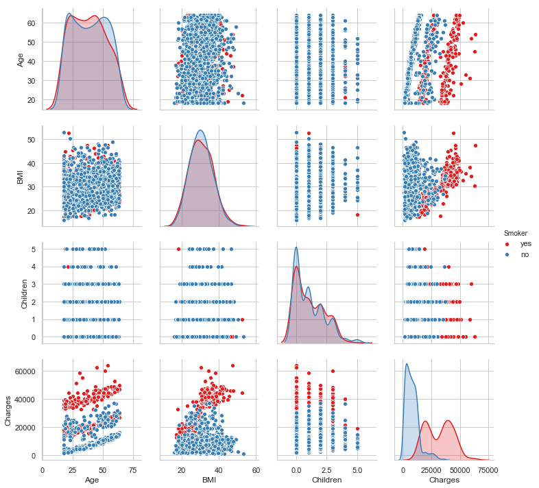

```python
sns.pairplot(df, hue = 'Smoker')
```

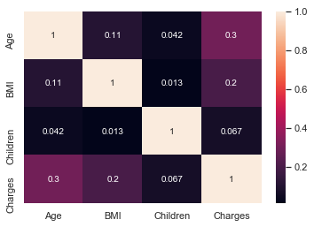

```python
corr = df.corr(method ='pearson')
sns.heatmap(corr, annot=True)
```

#### Study between Charges, BMI, Smoker and Age

- Below graphs demonstrate that charges increase based on BMI, Age and Smoking habits of the customer.
- There are three categories of charges within which charges gradually increase based on Age.
- Three categories are based on Non-smokers, Smokers with less than 30.4 BMI and Smokers with more than 30.4 BMI as derived earlier.

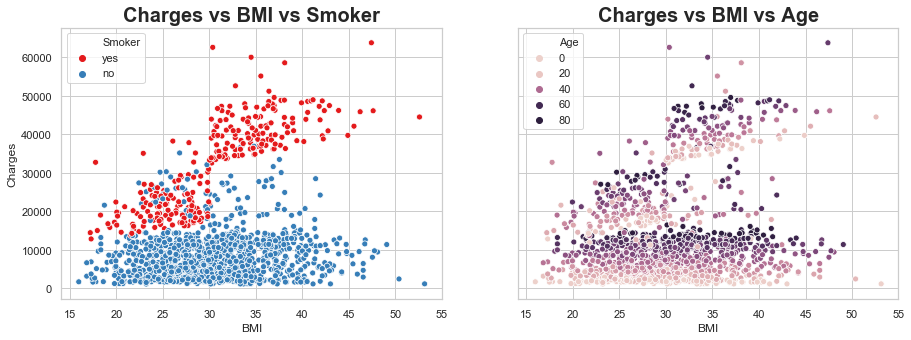

```python
f, ax = plt.subplots(1, 2, sharey = True, figsize = (15,5))
sns.scatterplot(x = df['BMI'], y = df['Charges'], hue = df['Smoker'],ax = ax[0])
ax[0].set_title("Charges vs BMI vs Smoker", size = 20, weight = "bold")
sns.scatterplot(x = df['BMI'], y = df['Charges'], hue = df['Age'],ax = ax[1])
ax[1].set_title("Charges vs BMI vs Age", size = 20, weight = "bold")
```

### Step 4A - Do charges of people who smoke differ significantly from the people who don't?

#### Step 1: State the null and alternative hypothesis:

- Null hypothesis: $H_0:$ Charges of people who smoke and do not smoke are same, $\mu_{Smokers} = \mu_{Non-Smokers}$
- Alternative hypothesis: $H_A:$ Charges of people who smoke and do not smoke are not same, $\mu_{Smokers} \neq \mu_{Non-Smokers}$
- Here $\mu$ is the mean insurance charges paid by smokers or non-smokers.

#### Step 2: Decide the significance level

- Selecting α = 0.05

#### Step 3: Identify the test statistic

- Since we have to check if the mean of two samples for charges $\overline {x}_{Smokers}$ and $\overline {x}_{Non-Smokers}$ are significantly different, selecting two sample t-test for mean.

$$t = {\dfrac {\overline {x}_1-\overline {x}_2}{\sqrt{{\dfrac {s^2_1}{n_1}}+{\dfrac {s^2_2}{n_2}}}}}$$

#### Step 4: Calculate p value

```python
group1 = df[df['Smoker'] == 'yes']['Charges']
group2 = df[df['Smoker'] == 'no']['Charges']
print(' x̄ 𝑆𝑚𝑜𝑘𝑒𝑟𝑠:', round(group1.mean(),4),"\n",'x̄ 𝑁𝑜𝑛−𝑆𝑚𝑜𝑘𝑒𝑟𝑠:', round(group2.mean(),4))

t_statistic, p_value = ttest_ind(group1, group2)
print('t-statistic is %1.6f' %(t_statistic), '| p-value is %1.6f' %(p_value))
```

```
 x̄ 𝑆𝑚𝑜𝑘𝑒𝑟𝑠: 32050.2318
 x̄ 𝑁𝑜𝑛−𝑆𝑚𝑜𝑘𝑒𝑟𝑠: 8440.6603
t-statistic is 46.644795 | p-value is 0.000000
```

#### Step 5: Decide to 'Reject' or 'Fail to reject' the null hypothesis

- Statistical evidence, p-value is 0.000000 and < 0.05 α so we *'Reject the null hypothesis'.*
- Supporting $H_A:$ Charges of people who smoke and do not smoke are significantly different, $\overline {x}_{Smokers} \neq \overline {x}_{Non-Smokers}$

### Step 4B - Does bmi of males differ significantly from that of females?

#### Step 1: State the null and alternative hypothesis:

- Null hypothesis: $H_0:$ BMI of males and females are same, $\mu_{Males} = \mu_{Females}$
- Alternative hypothesis: $H_A:$ BMI of males and females are not same, $ \mu_{Males} \neq \mu_{Females}$
- Here $\mu$ is the mean of bmi grouped by gender.

#### Step 2: Decide the significance level

- Selecting α = 0.05

#### Step 3: Identify the test statistic

- Since we have to check if the mean for two samples of BMI $\overline {x}_{Males}$ and $\overline {x}_{Females}$ are significantly different, selecting two sample t-test for mean.

$$t = {\dfrac {\overline {x}_1-\overline {x}_2}{\sqrt{{\dfrac {s^2_1}{n_1}}+{\dfrac {s^2_2}{n_2}}}}}$$

#### Step 4: Calculate p value

```python
group1 = df[df['Gender'] == 'male']['BMI']
group2 = df[df['Gender'] == 'female']['BMI']
print(' x̄ 𝑀𝑎𝑙𝑒𝑠:', round(group1.mean(),4),"\n",'x̄ 𝐹𝑒𝑚𝑎𝑙𝑒𝑠:', round(group2.mean(),4))

t_statistic, p_value = ttest_ind(group1, group2)
print(' p-value is %1.6f' %(p_value))
```

```
 x̄ 𝑀𝑎𝑙𝑒𝑠: 30.9437
 x̄ 𝐹𝑒𝑚𝑎𝑙𝑒𝑠: 30.3777
 p-value is 0.089917
```

### Step 4C - Is the proportion of smokers significantly different in different genders?

#### Step 1: State the null and alternative hypothesis:

- Null hypothesis: $H_0:$ Proportion of male and female smokers are same, $p̂_{Male-Smokers} = p̂_{Female-Smokers}$
- Alternative hypothesis: $H_A:$ Proportion of male and female smokers are not same, $p̂_{Male-Smokers} \neq p̂_{Female-Smokers}$

#### Step 2: Decide the significance level

- Selecting α = 0.05

#### Step 3: Identify the test statistic

- Since we have to check if the proportion for two samples of Smokers $p̂_{Male-Smokers}$ and $p̂_{Female-Smokers}$ are significantly different and sample size is above 30, selecting z-test of proportion for two samples.

$$z = {\dfrac {(p̂_1-p̂_2)}{{\sqrt {p̂\left(1-p̂\right)}}{\sqrt{{\dfrac {1}{n_1}}+{\dfrac {1}{n_2}}}}}}$$

#### Step 4: Calculate p value

```python
# Contingency table of smokers based on gender
df_smoker = pd.crosstab(df['Smoker'], df['Gender'], margins = True)
Smoker_Male = (df_smoker.loc['yes','male'])/(df_smoker.loc['All','male'])
Smoker_Female = (df_smoker.loc['yes','female'])/(df_smoker.loc['All','female'])
print(' 𝑝̂ 𝑀𝑎𝑙𝑒−𝑆𝑚𝑜𝑘𝑒𝑟𝑠:', round(Smoker_Male,2), "\n", '𝑝̂ 𝐹𝑒𝑚𝑎𝑙𝑒−𝑆𝑚𝑜𝑘𝑒𝑟𝑠:', round(Smoker_Female,2))

df_smoker
```

```
 𝑝̂ 𝑀𝑎𝑙𝑒−𝑆𝑚𝑜𝑘𝑒𝑟𝑠: 0.24
 𝑝̂ 𝐹𝑒𝑚𝑎𝑙𝑒−𝑆𝑚𝑜𝑘𝑒𝑟𝑠: 0.17
```

| Gender Smoker | female | male | All |
| --- | --- | --- | --- |
| no | 547 | 516 | 1063 |
| yes | 115 | 159 | 274 |
| All | 662 | 675 | 1337 |

```python
# Calculate p-value
z_statistic, p_value = proportions_ztest([df_smoker.loc['yes','female'], df_smoker.loc['yes','male']] , [df_smoker.loc['All','female'], df_smoker.loc['All','male']])
print('p-value is %1.6f' %(p_value))
```

```
p-value is 0.005099
```

### Step 4D - Is the distribution of bmi across women with no children, one child and two children, the same?

#### Step 1: State the null and alternative hypothesis:

- Null hypothesis: $H_0:$ Distribution of BMI across women with no child, one child and two children are same, $\mu_{0-Child} = \mu_{1-Child} = \mu_{2-Children}$
- Alternative hypothesis: $H_A:$ At least one $\mu$ is significantly different among $\mu$ of BMI distribution in women with no child, one child and two children.

#### Step 2: Decide the significance level

- Selecting α = 0.05

#### Step 3: Identify the test statistic

- Since we have to check if the distribution for more than two samples of BMI across women with $\mu_{0-Child}$, $\mu_{1-Child}$ and $\mu_{2-Children}$ are significantly different among each other, selecting analysis of variance (ANOVA), as it can determine whether the mean of one among three or more groups are different.

$$F-statistic = {\dfrac {\dfrac {SSB}{m-1}}{\dfrac {SSW}{m(n-1)}}}$$

#### Step 4: Calculate p value

```python
df_Child = pd.DataFrame()
df_Child = df_Child.append(pd.DataFrame({'Children': 'C0', 'BMI':df[(df['Children'] == 0) & (df['Gender'] == 'female')]['BMI']}))
df_Child = df_Child.append(pd.DataFrame({'Children': 'C1', 'BMI':df[(df['Children'] == 1) & (df['Gender'] == 'female')]['BMI']}))
df_Child = df_Child.append(pd.DataFrame({'Children': 'C2', 'BMI':df[(df['Children'] == 2) & (df['Gender'] == 'female')]['BMI']}))
print(' x̄0−𝐶ℎ𝑖𝑙𝑑:', round(df[(df['Children'] == 0) & (df['Gender'] == 'female')]['BMI'].mean(),4),
      "\n",'x̄1−𝐶ℎ𝑖𝑙𝑑:', round(df[(df['Children'] == 1) & (df['Gender'] == 'female')]['BMI'].mean(),4),
      "\n",'x̄2−𝐶ℎ𝑖𝑙𝑑𝑟𝑒𝑛:', round(df[(df['Children'] == 2) & (df['Gender'] == 'female')]['BMI'].mean(),4))
```

```
 x̄0−𝐶ℎ𝑖𝑙𝑑: 30.3615
 x̄1−𝐶ℎ𝑖𝑙𝑑: 30.0527
 x̄2−𝐶ℎ𝑖𝑙𝑑𝑟𝑒𝑛: 30.6498
```

```python
# Calculate p-value
model = ols('BMI ~ Children', data = df_Child).fit() #'Values ~ Category'(m)
aov_table = sm.stats.anova_lm(model, typ=2)
print(aov_table) # (SSB=(SumSq/df))/(SSW=(SumSq/df)), F-Statistic, P-Value
```

```
                sum_sq     df         F    PR(>F)
Children     24.590123    2.0  0.334472  0.715858
Residual  20695.661583  563.0       NaN       NaN
```

#### Step 5: Decide to 'Reject' or 'Fail to reject' the null hypothesis

- Statistical evidence, p-value is 0.715858 and > 0.05 so we *'Fail to reject the null hypothesis'.*
- Supporting $H_0:$ Distribution of BMI across no child, one child and two children are same, $\mu_{0-Child} = \mu_{1-Child} = \mu_{2-Children}$

```python
print(pairwise_tukeyhsd(df_Child['BMI'], df_Child['Children']))
```

```
Multiple Comparison of Means - Tukey HSD,FWER=0.05
============================================
group1 group2 meandiff  lower  upper  reject
--------------------------------------------
  C0     C1   -0.3089  -1.7186 1.1008 False
  C0     C2    0.2883  -1.2636 1.8402 False
  C1     C2    0.5971  -1.1323 2.3265 False
--------------------------------------------
```

## Summary

Data provided insurance.csv had 1338 observation (rows) and 7 variables (columns). It did not have any missing values. It contained a duplicate value that was dropped before analysis.

*Seven columns contained below attributes:*

**Age:** A 'Uniform Distribution' of discrete variables from 18 to 64 years. The counts for age 18 and 19 years are more than double in comparison to rest of the age groups. Mean age is 39 years

**Gender:** A binary categorical variable had 49.5% females and 50.5% males. Proportion of males in southeast are 4% more relative to females in same region.

**BMI:** A 'Normally Distributed' continuous variable with median of 30.4 and mean of 30.66 that is very close to symmetric with a small positive skew of 0.28. It has few outliers on the right side of distribution that are beyond 1.5 times of IQR. There is no significant difference in BMI between males and females at a p-value of 0.089 that is greater than 0.05 α. It is also statistically evident that BMI of women with no child, one child or two children are same with a p-value of 0.7158 which is greater than the considered significance level of 0.05.

**Children:** A discrete variable with values ranging from 0 to 5 dependents. 42.9% of primary beneficiaries do not have children, 24.2% have one child, 18% have two children, 11.7% have three, 1.9% with four and 1.3% with 5 children.

**Region:** A nominal categorical variable mentioning beneficiary's residential area in the US, northeast, southeast, southwest, northwest. Proportion of smokers in southeast are 5% more than average smokers of US. Proportion of primary beneficiaries with no or one child are 7% higher in Southeast relative to Northwest.

**Charges:** A continuous variable that shows individual medical costs billed by health insurance. Median of 9386 and mean of 13279 shows a huge right skew by 1.51, if considered as a whole. It also has some outliers on the right side beyond 1.5 times of IQR when the charges are considered as one data.